# Homework1

Allen Wang

2022-03-31

# Machine Learning Main Idea

## Question 1

Supervised learning: Situation when for each observation of the predictor measurements $x_i, i = 1,2,...n$ there is an associated response measurement $y_i$. Unsupervised learning: situation when for every observation $i=1,...,n$, we observe a vector of measurements $x_i$ but no associated response $y_i$.  
The difference is that whether there is a **response variable** or not.

## Question 2

Regression model is used when the response variable is quantitative; classification model is used when the response variable is qualitative.

## Question 3

Mean Squared Error(MSE) and R-Squared($R^2$) are commonly used for regression model.  
Accuracy and F1-score are commonly used for classification model.

## Question 4

Descriptive model is used to best visually emphasize a trend in data.  
Predictive model aims to predict $Y$ with minimum reducible error. It does not focus on hypothesis tests.  
Inferential model aims to test theories and causal claims, such as relationship between outcomes and predictors.

## Question 5

- In the mechanistic context, we make an assumption about the functional form and then use the training data to *fit* or *train* the model. In the empirically-driven context, we do not make explicit assumptions about the functional form of $f$.

Simply, mechanistic approach reduces the problem of estimating $f$ to one of estimating a set of parameters, but the model may not fit the data well. But, empirically-driven method avoids this problem; instead, it can produce a accurate estimate of $f$. Also, empirically-driven method requires a larger number of observations.Consider the sameness, these two methods all may cause overfitting in different situations.

- From my understanding, mechanistic approach is easier to understand as long as we have a clear assumption about the model type. We only need to learn the model and derive its parameters with the training data. However, it may be hard to determine an exact model. Empirically-driven model can be hard to explained since the model can be very complex in order to fit the data.
- Since empirically-driven model has higher model flexibility than the one of mechanistic model by default, it may have low bias and high variance. In contrast, if the mechanistic is simple by assumption, it gives us high bias and low variance.

## Question 6

Predictive: the model should try to predict the binary response variable vote, which is Yes or not, based on the voter’s data(predictor variables).

Inferential: we are expected to find the relationship between the likelihood of support for the candidate and the personal contact with the candidate. A possible causal theory is tested, and the personal contact should stand out as a feature relating to voting preference.

# Exploratory Data Analysis

## Question 1

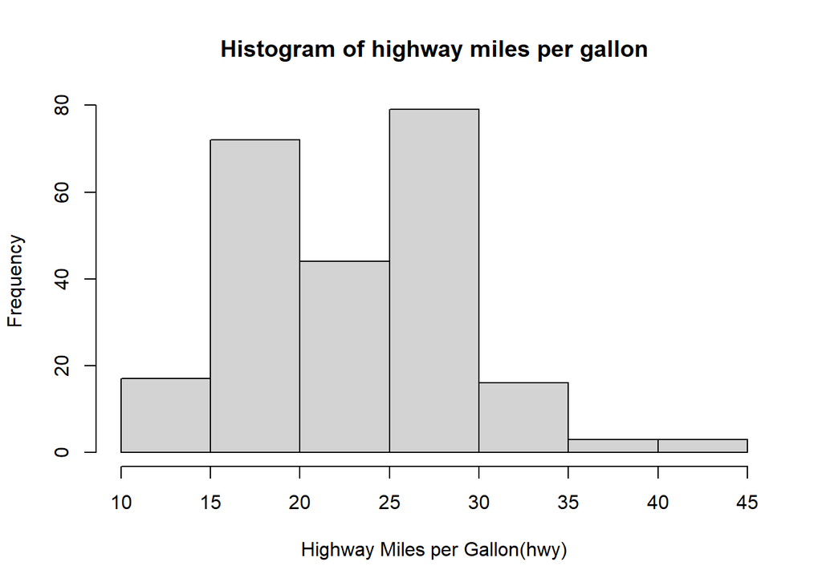

```r
library(tidyverse)
library(ggplot2)
hist(mpg$hwy,main="Histogram of highway miles per gallon",
     xlab = "Highway Miles per Gallon(hwy)")
```

From this graph, we see that hwy ranges from 10 to 45 highway miles per gallon. Also, the majority of cars’ hwy stays between the range $[15,30]$.

## Question 2

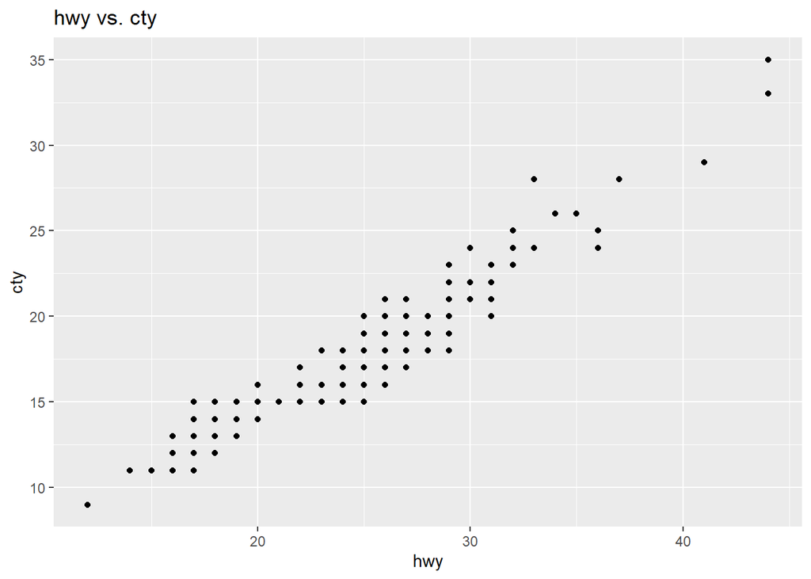

```r
ggplot(mpg, aes(x=hwy, y=cty)) + geom_point()+labs(title="hwy vs. cty")
```

There is a significant positive relationship between hwy and cty. This means that an increase of hwy is likely to correspond to an increase of cty.

## Question 3

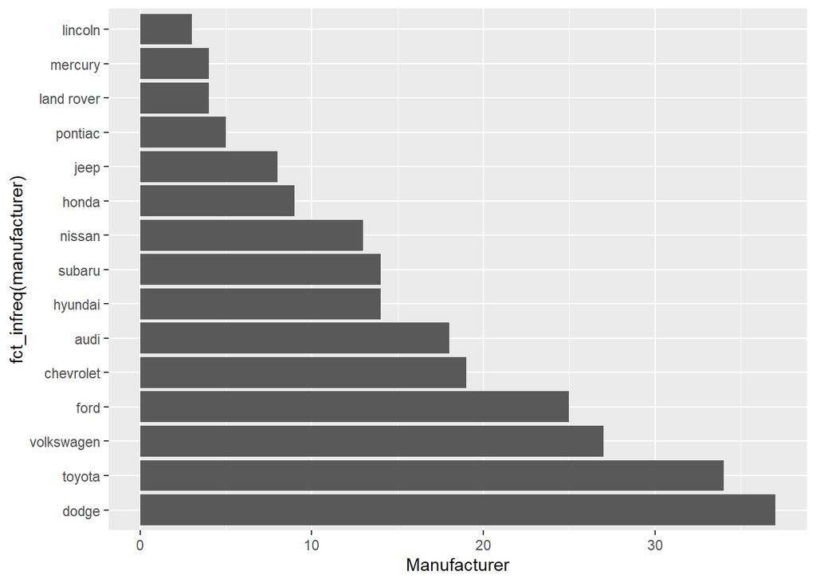

```r
library(forcats)
mpg %>%
  ggplot(aes(x=fct_infreq(manufacturer))) + geom_bar() +
  coord_flip() + labs(y="Manufacturer")
```

Dodge produces the most cars; Lincoln produces the least cars.

## Question 4

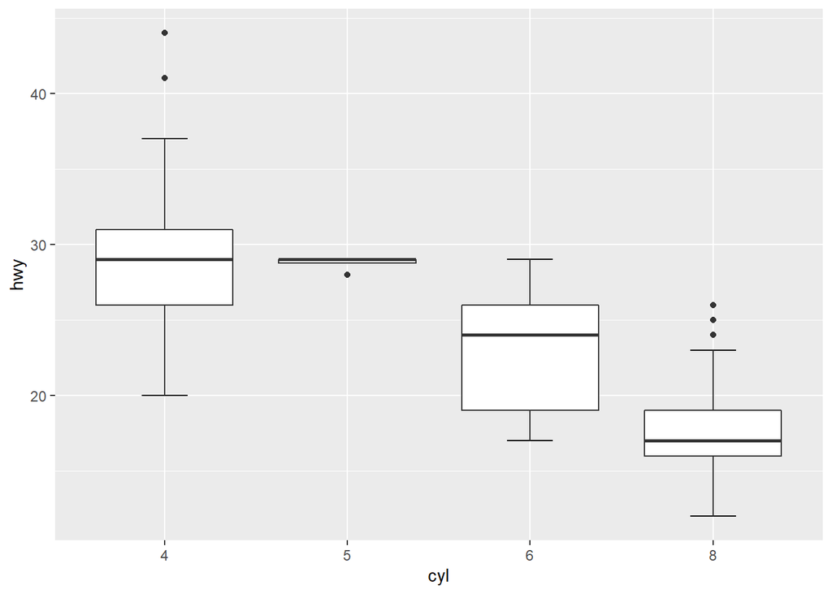

```r
ggplot(mpg, aes(x=as.character(cyl), y=hwy)) +
  stat_boxplot(geom = "errorbar", width = 0.25) +
  geom_boxplot() + labs(x="cyl")
```

Yes, I see a pattern. As cyl increases, there is a pattern that the average of hwy decreases.

## Question 5

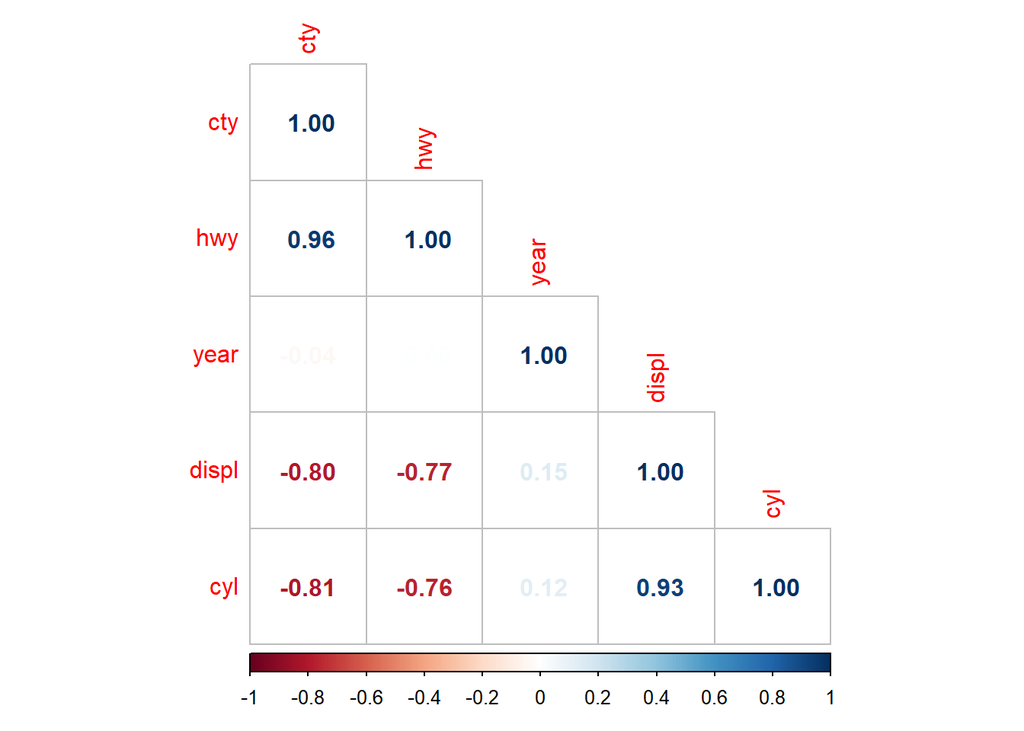

```r
library(corrplot)
library(dplyr)
mpg_new <- select_if(mpg, is.numeric)

M = cor(mpg_new)
corrplot(M, method = 'number',order = 'FPC', type = 'lower', diag = TRUE)
```

Here, I exclude the categorical variables from the correlation matrix. Only consider significant correlation, (cty,hwy) and (cyl,displ) have positive correlation. First, it is reasonable that highway miles per gallon increases as city miles per gallon increase. These two variables all relate to cars’ oil consumption speed. Secondly, displacement is the total volume of all the cylinders in the car. So, an increase of cylinders means an increase of displacement.

There are four pairs of variables which have negative correlation: (displ,cty), (displ,hwy), (cyl,cty), and (cyl,hwy). Cars with large displacement and more cylinders sacrifice cty and hwy for better acceleration, this is because cars with large displacement always consume gasoline quickly. Fast gasoline consumption contributes to the decrease of hwy and cty.

Therefore, these relationships make sense to me.